# Restricted Mean Survival Time in Practice

Implementation of RMST analysis

Angel Cronin, Xiang Meng, and Hajime Uno

# Regression analysis with RMST

**Regression model:**

$$\begin{equation*}
\color{blue}{g\{E(T \wedge \tau | Z, X )\} = \alpha + \beta Z + \gamma ' X}
\end{equation*}$$

- $T \wedge \tau$ = RMST
- $Z$ treatment indicator
- $X$ covariate(s)
- $\alpha$ intercept
- Link function g($x$):
  - g($x$) = $x$ for difference in RMST
  - g($x$) = log($x$) for ratio of RMST
  - g($\tau$ - $x$) for ratio of RMTL

**Inverse-probability censoring weighted estimation equation to fit the model parameters:**

$$\begin{equation*}
\sum_{i=1}^{n} {\color{blue}{\frac{I(T_i \wedge \tau \leq C_i)}{\widehat{K}(T_i \wedge \tau)}}} (1, Z_i, X_i')' \bigg[ T_i \wedge \tau - g^{-1} (\alpha + \beta Z_i + \gamma ' X_i) \bigg] = 0
\end{equation*}$$

- For the weight:
  - The denominator, $\widehat{K}(t)$, is the Kaplan-Meier estimator of the survival function of the censoring time $C$.
  - The numerator represents the indicator function that a patient was not censored before $\tau$.

# Regression Analysis Worked Example

**Regression Analysis Setup (1 of 2):** These are the same packages as used for Part 1, with the addition of gt.

```r
library(tidyverse)
library(survminer)
library(gt)
library(devtools)
devtools::install_github("uno1lab/survRM2")
library(survRM2)
```

**Notes**

- Install tidyverse, survminer, gt, and devtools packages, if needed.
- The survRM2 package is also available for installation through CRAN. However, Hajime’s GitHub repo will have the most up-to-date version.

**Regression Analysis Setup (2 of 2):** The example uses the Mayo Clinic Primary Biliary Cholangitis dataset.

After loading the data, we perform basic data manipulation to create the dataset used in the examples.

```r
data(pbc, package="survival")
df <- pbc %>%
  filter(!is.na(trt)) %>%
  mutate(status = if_else(status==2, 1, 0),
         arm = if_else(trt==1, 1, 0),
         time = time / 365.25) %>%
  select(id, time, status, arm, age, edema, bili, albumin, protime)
```

**Note**

If the survRM2 package is installed from GitHub, this edited dataset can be retrieved by **df <- rmst2.sample.data()**

Recall the unadjusted two-sample analysis:

```r
result1 <- rmst2(time=df$time,     # analysis time
                status=df$status, # event indicator
                arm=df$arm,       # study arm (independent variable of interest)
                tau=10)           # truncation time
```

For the adjusted regression analysis:  
- we make a data frame with just the covariates  
- we pass that data frame to the **covariates argument**

```r
covdf <- df[, c("age", "bili", "albumin")]
result2 <- rmst2(time=df$time,
                 status=df$status,
                 arm=df$arm,
                 covariates=covdf,
                 tau=10)
```

Table of summary statistics

```r
print(result2)
```

```
The truncation time: tau = 10  was specified.

Summary of between-group contrast (adjusted for the covariates)
                       Est. lower .95 upper .95     p
RMST (arm=1)-(arm=0) -0.210    -0.883     0.463 0.540
RMST (arm=1)/(arm=0)  0.968     0.877     1.068 0.514
RMTL (arm=1)/(arm=0)  1.035     0.806     1.329 0.786


Model summary (difference of RMST)
            coef se(coef)      z     p lower .95 upper .95
intercept  2.743    2.134  1.285 0.199    -1.440     6.927
arm       -0.210    0.343 -0.613 0.540    -0.883     0.463
age       -0.069    0.018 -3.900 0.000    -0.103    -0.034
bili      -0.325    0.039 -8.386 0.000    -0.401    -0.249
albumin    2.550    0.472  5.401 0.000     1.624     3.475


Model summary (ratio of RMST)
            coef se(coef)      z     p exp(coef) lower .95 upper .95
intercept  1.369    0.356  3.842 0.000     3.930     1.955     7.899
arm       -0.033    0.050 -0.652 0.514     0.968     0.877     1.068
age       -0.009    0.003 -3.410 0.001     0.991     0.985     0.996
bili      -0.087    0.013 -6.523 0.000     0.917     0.893     0.941
albumin    0.360    0.080  4.491 0.000     1.434     1.225     1.678


Model summary (ratio of time-lost)
            coef se(coef)      z     p exp(coef) lower .95 upper .95
intercept  1.992    0.695  2.865 0.004     7.332     1.876    28.655
arm        0.035    0.127  0.272 0.786     1.035     0.806     1.329
age        0.025    0.007  3.810 0.000     1.026     1.012     1.039
bili       0.063    0.008  8.334 0.000     1.065     1.049     1.080
albumin   -0.750    0.149 -5.033 0.000     0.472     0.353     0.633
```

Comparison of unadjusted and unadjusted results for RMST difference

**Unadjusted**

|  | Est. | lower .95 | upper .95 | p |
| --- | --- | --- | --- | --- |
| RMST (arm=1)-(arm=0) | −0.137 | −0.939 | 0.665 | 0.738 |
| RMST (arm=1)/(arm=0) | 0.981 | 0.878 | 1.096 | 0.738 |
| RMTL (arm=1)/(arm=0) | 1.050 | 0.787 | 1.402 | 0.738 |

**Adjusted**

|  | coef | se(coef) | z | p | lower .95 | upper .95 |
| --- | --- | --- | --- | --- | --- | --- |
| intercept | 2.743 | 2.134 | 1.285 | 0.199 | −1.440 | 6.927 |
| arm | −0.210 | 0.343 | −0.613 | 0.540 | −0.883 | 0.463 |
| age | −0.069 | 0.018 | −3.900 | 0.000 | −0.103 | −0.034 |
| bili | −0.325 | 0.039 | −8.386 | 0.000 | −0.401 | −0.249 |
| albumin | 2.550 | 0.472 | 5.401 | 0.000 | 1.624 | 3.475 |

# RMST for Stratified Analysis of Survival Data

## Stratified Analysis of Survival Data

- For comparative studies, it is common to conduct analysis stratified by key baseline factors known to be associated with the outcome.
  - Stratified analysis may increase precision or reduce bias.
- The between-group difference (treatment effect) is typically summarized with a stratified hazard ratio (HR).

## Issues of Conventional Analysis

**Stratified Cox Regression:**

- Assumes a common between-group difference (HR) across strata
- Assumes the proportional hazards assumption in each stratum
- As with unstratified analysis, there is a lack of reference hazard from the control group

## Stratified analysis using RMST

**Method:**

1. Get the RMST for each group for each stratum.
2. Using the stratum sizes (sample size) as the weight, calculate the weighted average of the RMST for each group.
3. The between-group difference is obtained by taking the the difference or ratio of the weighted-average RMST. (Deriving the standard error is trivial.)

Note: the selection of $\tau$ can be tricky if there are too many strata.

## Stratified analysis using RMST

**Example calculation:**

| Stratum | Sample Size | RMST: Group 1 | RMST: Group 0 | RMST Difference |
| --- | --- | --- | --- | --- |
| Male | 40 | 10m | 8m |  |
| Female | 60 | 20m | 20m |  |
| **Weighted-average** |  | **16m** = [10(40/100) + 20(60/100)] | **15.2m** = [8(40/100) + 20(60/100)] | **0.8m** = (16.0 - 15.2) |

# Stratified Analysis Worked Example

**Stratified Analysis Setup**

Stratified analysis can be implemented using the StratSurv package by Zachary McCaw (https://github.com/zrmacc/StratSurv).

```r
devtools::install_github("zrmacc/StratSurv")
library(StratSurv)
```

The example uses data reconstructed from the KEYNOTE-189 study.

```r
df_strata <- read.csv("training_data/keynote189-stratified.csv")
```

Let’s take a look at the example data.

```r
head(df_strata)
```

```
       time status arm stratum
1 0.4096012      1   1       0
2 0.5818543      1   1       0
3 0.7371316      1   1       0
4 1.2914028      1   1       0
5 1.3801056      1   1       0
6 1.9061661      1   1       0
```

Stratum represents tumor proportion score:  
0 for <1%, 1 for 1%-49%, and 2 for >=50%

```r
table(df_strata$stratum)
```

```
  0   1   2
190 186 202
```

[figure not shown]

Let’s look at the Kaplan-Meier plots stratified by tumor proportion score.

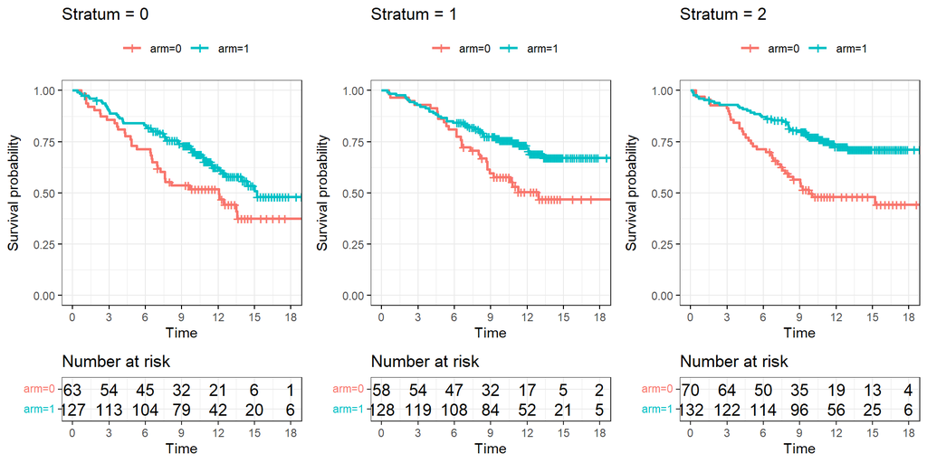

Let’s perform an unadjusted analysis of RMST by study arm, stratified by tumor proportion score, using a trunction timepoint of 18 months.

```r
result <- StratRMST(time = df_strata$time,
                    status = df_strata$status,
                    arm = df_strata$arm,
                    strata = df_strata$stratum,
                    tau = 18)
```

Default table of summary statistics

```r
print(result)
```

```
Marginal Statistics:
# A tibble: 4 × 6
    arm stat    est    se lower upper
  <dbl> <chr> <dbl> <dbl> <dbl> <dbl>
1     0 RMST  11.5  0.468 10.6  12.4
2     0 RMTL   6.53 0.468  5.61  7.44
3     1 RMST  14    0.305 13.4  14.6
4     1 RMTL   3.98 0.305  3.38  4.58


Contrasts:
# A tibble: 4 × 6
  stat  contrast    est  lower  upper          p
  <chr> <chr>     <dbl>  <dbl>  <dbl>      <dbl>
1 RMST  A1-A0     2.55   1.46   3.65  0.000005
2 RMST  A1/A0     1.22   1.12   1.34  0.0000141
3 RMTL  A1-A0    -2.55  -3.65  -1.46  0.000005
4 RMTL  A1/A0     0.609  0.496  0.749 0.00000239
```

Within-stratum estimates of RMST by study arm:

```r
result@Stratified
```

```
# A tibble: 12 × 9
   strata   arm   tau stat    est    se lower upper weight
    <int> <dbl> <dbl> <chr> <dbl> <dbl> <dbl> <dbl>  <dbl>
 1      0     0    18 RMST  10.9  0.829  9.26 12.5   0.329
 2      0     0    18 RMTL   7.11 0.829  5.49  8.74  0.329
 3      0     1    18 RMST  13.0  0.559 11.9  14.1   0.329
 4      0     1    18 RMTL   4.99 0.559  3.89  6.08  0.329
 5      1     0    18 RMST  12.2  0.809 10.6  13.8   0.322
 6      1     0    18 RMTL   5.82 0.809  4.24  7.41  0.322
 7      1     1    18 RMST  14.3  0.525 13.3  15.4   0.322
 8      1     1    18 RMTL   3.66 0.525  2.64  4.69  0.322
 9      2     0    18 RMST  11.4  0.793  9.82 12.9   0.349
10      2     0    18 RMTL   6.63 0.793  5.08  8.18  0.349
11      2     1    18 RMST  14.7  0.504 13.7  15.7   0.349
12      2     1    18 RMTL   3.31 0.504  2.33  4.30  0.349
```

Stratum-sized weighted-averages of RMST by study arm and underlying weights:

```r
result@Marginal
```

```
# A tibble: 4 × 6
    arm stat    est    se lower upper
  <dbl> <chr> <dbl> <dbl> <dbl> <dbl>
1     0 RMST  11.5  0.468 10.6  12.4
2     0 RMTL   6.53 0.468  5.61  7.44
3     1 RMST  14.0  0.305 13.4  14.6
4     1 RMTL   3.98 0.305  3.38  4.58
```

```r
result@Weights
```

```
# A tibble: 3 × 4
  strata    n0    n1 weight
   <int> <int> <int>  <dbl>
1      0    63   127  0.329
2      1    58   128  0.322
3      2    70   132  0.349
```

Between-group differences of RMST from stratified analysis:

```r
result@Contrasts
```

```
# A tibble: 4 × 6
  stat  contrast    est  lower  upper          p
  <chr> <chr>     <dbl>  <dbl>  <dbl>      <dbl>
1 RMST  A1-A0     2.55   1.46   3.65  0.00000500
2 RMST  A1/A0     1.22   1.12   1.34  0.0000141
3 RMTL  A1-A0    -2.55  -3.65  -1.46  0.00000500
4 RMTL  A1/A0     0.609  0.496  0.749 0.00000239
```

Summary of results – RMST through 18 months

| Stratum | RMST: Arm 0 | RMST: Arm 1 | RMST Difference (Arm 1 - Arm 0) |
| --- | --- | --- | --- |
| Stratum 0 | 10.9 | 13.0 | 2.12 |
| Stratum 1 | 12.2 | 14.3 | 2.16 |
| Stratum 2 | 11.4 | 14.7 | 3.31 |
| Marginal (weighted-average) | 11.5 | 14.0 | 2.55 (95 CI 1.46 to 3.65 ) |

**Interpretation:**

A randomly selected patient followed for 18 months is expected to survive 14.0 months if treated with pembrolizumab (arm 1) versus 11.5 months if not treated (arm 0). The difference of 2.55 months (95% CI 1.46 to 3.65 months, p<0.001) favors the treatment group.

# Exercise

**Exercise: Regression analysis**

rmst-regression-example-data.csv contains data from a randomized trial that investigated the efficacy of a novel treatment (intervention) compared with standard of care (control) in patients with non-small cell lung cancer.

**Exercise: Regression analysis**

```r
df <- read.csv("training_data/rmst-regression-example-data.csv")
```

-time: observed time to death or censoring (months)  
-status: 1=dead, 0=censored  
-arm: 1=intervention, 0=control  
-age: age (years)  
-male: 1=male sex, 0=female sex  
-ecogps: 1=ECOG PS 1+, 0=ECOG PS 0  
-white: 1=white race, 0=non-white race

**The investigator would like to understand the effect of the intervention versus control on overall survival, with adjustment for prognostic factors (age, sex, ECOG PS, and race).**

*Work on for 5-10 minutes and then we will review.*

**Exercise: Regression analysis**  
Let’s look at the data

```r
head(df)
```

```
  X       time status arm age male ecogps white
1 1  3.2854209      1   0  78    0      1     1
2 2 13.0102669      0   1  65    0      1     1
3 3  2.2669405      1   0  50    1      1     1
4 4  0.1971253      1   0  63    0      1     1
5 5 24.2792608      0   1  59    0      1     0
6 6  9.7248460      1   1  53    1      1     1
```

**Exercise: Regression analysis**  
Let’s look at the Kaplan-Meier plot

```r
ggsurvplot(survfit(Surv(time, status) ~ arm, data=df),
           data = df, legend.title = "",
           risk.table = TRUE,
           xlim = c(0, 28),
           break.x.by=4,
           ggtheme = theme_bw())
```

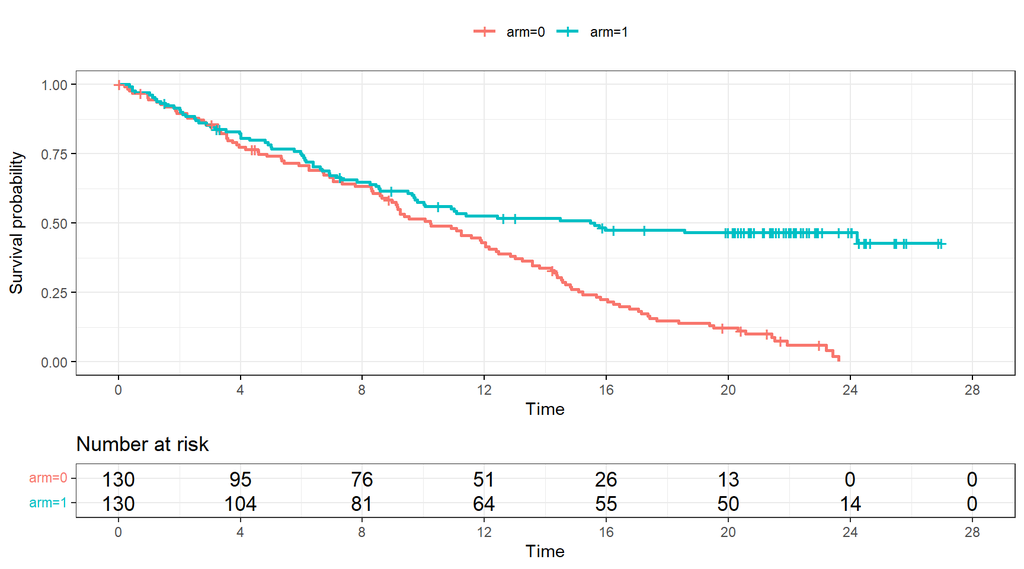

**Exercise: Regression analysis**  
Adjusted analysis of RMST by study arm using a trunction timepoint of 20 months

```r
covdf <- df[, c("age", "male", "ecogps", "white")]
result2 <- rmst2(time=df$time,
                 status=df$status,
                 arm=df$arm,
                 covariates=covdf,
                 tau=20)
```

**Exercise: Regression analysis**  
Table of summary statistics

```r
print(result2)
```

```
The truncation time: tau = 20  was specified.

Summary of between-group contrast (adjusted for the covariates)
                      Est. lower .95 upper .95     p
RMST (arm=1)-(arm=0) 2.099     0.424     3.774 0.014
RMST (arm=1)/(arm=0) 1.197     1.037     1.383 0.014
RMTL (arm=1)/(arm=0) 0.775     0.628     0.956 0.017


Model summary (difference of RMST)
            coef se(coef)      z     p lower .95 upper .95
intercept 13.653    2.941  4.642 0.000     7.889    19.418
arm        2.099    0.855  2.456 0.014     0.424     3.774
age        0.015    0.045  0.341 0.733    -0.072     0.103
male      -1.047    0.786 -1.331 0.183    -2.588     0.495
ecogps    -2.534    0.891 -2.843 0.004    -4.281    -0.787
white     -2.238    1.041 -2.149 0.032    -4.278    -0.197


Model summary (ratio of RMST)
            coef se(coef)      z     p exp(coef) lower .95 upper .95
intercept  2.597    0.251 10.344 0.000    13.430     8.210    21.970
arm        0.180    0.074  2.449 0.014     1.197     1.037     1.383
age        0.001    0.004  0.343 0.732     1.001     0.994     1.009
male      -0.089    0.066 -1.347 0.178     0.915     0.804     1.041
ecogps    -0.210    0.073 -2.861 0.004     0.811     0.702     0.936
white     -0.180    0.081 -2.217 0.027     0.835     0.712     0.979


Model summary (ratio of time-lost)
            coef se(coef)      z     p exp(coef) lower .95 upper .95
intercept  1.812    0.365  4.960 0.000     6.125     2.993    12.536
arm       -0.255    0.107 -2.380 0.017     0.775     0.628     0.956
age       -0.002    0.005 -0.335 0.738     0.998     0.988     1.009
male       0.127    0.098  1.294 0.196     1.136     0.937     1.377
ecogps     0.324    0.121  2.682 0.007     1.382     1.091     1.752
white      0.298    0.152  1.963 0.050     1.348     1.001     1.815
```

**Summary of software for implementation of RMST analysis**

- Adjusted analysis
  - R: survRM2::rmst2
  - Stata: -strmst2- from the strmst2 package
  - SAS: PROC RMSTREG
- Stratified analysis
  - R: StratSurv
- Study design
  - R: SSRMST, RMSTDesign

**References for software**

**R**  
https://github.com/uno1lab/survRM2  
https://cran.r-project.org/web/packages/survRM2/index.html https://github.com/zrmacc/StratSurv https://cran.r-project.org/web/packages/SSRMST/index.html https://anneae.github.io/RMSTdesign/

**Stata**  
https://ideas.repec.org/c/boc/bocode/s458154.html  
https://www.stata-journal.com/article.html?article=st0451

**SAS**  
https://documentation.sas.com/doc/en/statug/15.2/statug_rmstreg_overview.htm

## For reference: adjusted analysis in **Stata**

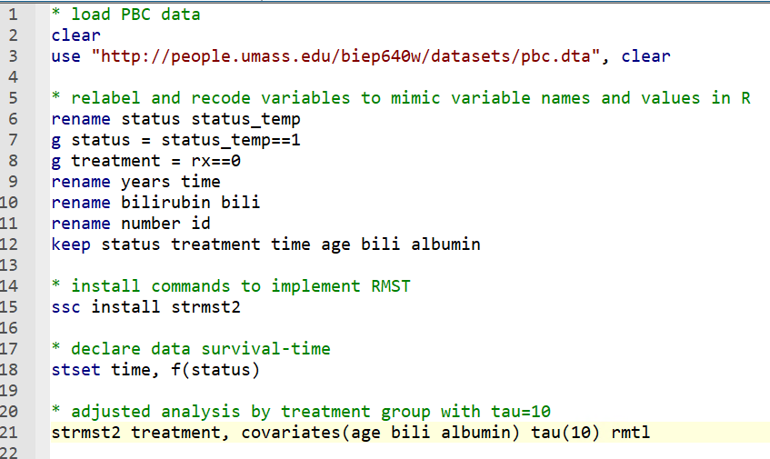

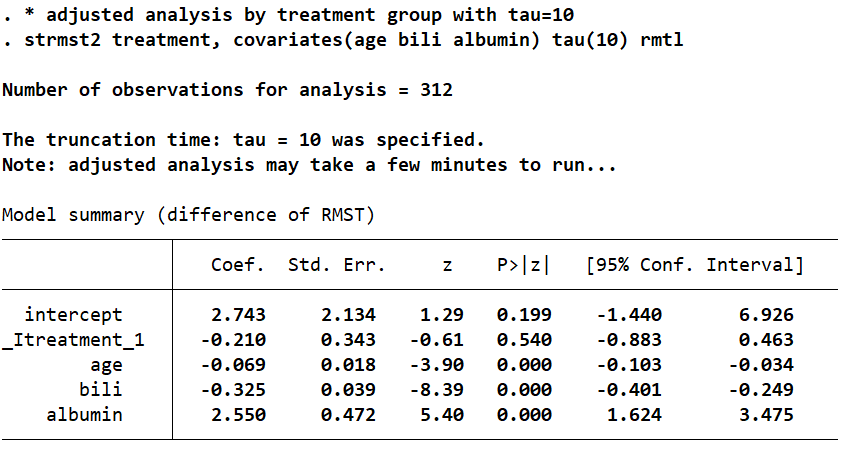

## For reference: adjusted analysis in **SAS**

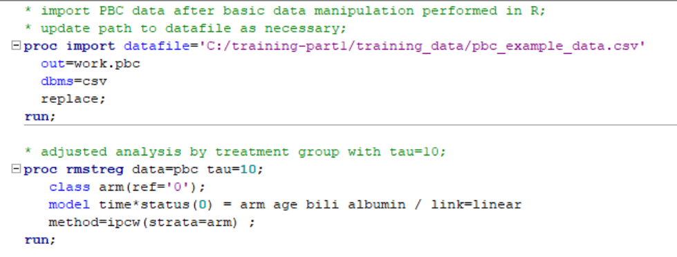

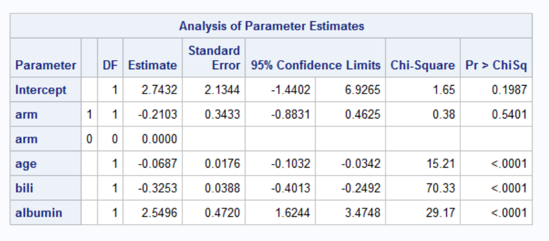

**Note**

Without specifying the (strata=arm) option, the RMSTREG procedure will produce slightly different results from those R/Stata, because a common censoring distribution is assumed in RMSTREG by default.